# Лабораторная работа №9

ДИОН ГОНССАН СЕДРИК МИШЕЛ

RUDN University, Moscow, Russian Federation

## Цель работы

Познакомиться с операционной системой Linux. Получить практические навыки работы с редактором Emacs.

## Задание

Последовательность выполнения работы 1. Ознакомиться с теоретическим материалом. 2. Ознакомиться с редактором emacs. 3. Выполнить упражнения. 4. Ответить на контрольные вопросы.

Основные команды emacs 1. Открыть emacs. 2. Создать файл lab07.sh с помощью комбинации Ctrl-x Ctrl-f (C-x C-f). 3. Наберите текст, который дан. 4. Сохранить файл с помощью комбинации Ctrl-x Ctrl-s (C-x C-s). 5. Проделать с текстом стандартные процедуры редактирования, каждое действие должно осуществляться комбинацией клавиш. 5.1. Вырезать одной командой целую строку (С-k). 5.2. Вставить эту строку в конец файла (C-y). 5.3. Выделить область текста (C-space). 5.4. Скопировать область в буфер обмена (M-w). 5.5. Вставить область в конец файла. 5.6. Вновь выделить эту область и на этот раз вырезать её (C-w). 5.7. Отмените последнее действие (C-/).

## Задание

6. Научитесь использовать команды по перемещению курсора. 6.1. Переместите курсор в начало строки (C-a). 6.2. Переместите курсор в конец строки (C-e). 6.3. Переместите курсор в начало буфера (M-<). 6.4. Переместите курсор в конец буфера (M->).
7. Управление буферами. 7.1. Вывести список активных буферов на экран (C-x C-b). 7.2. Переместитесь во вновь открытое окно (C-x) o со списком открытых буферов и переключитесь на другой буфер. 7.3. Закройте это окно (C-x 0). 7.4. Теперь вновь переключайтесь между буферами, но уже без вывода их списка на экран (C-x b).

## Задание

8. Управление окнами. 8.1. Поделите фрейм на 4 части: разделите фрейм на два окна по вертикали (C-x 3), а затем каждое из этих окон на две части по горизонтали (C-x 2). 8.2. В каждом из четырёх созданных окон откройте новый буфер (файл) и введите несколько строк текста.
9. Режим поиска 9.1. Переключитесь в режим поиска (C-s) и найдите несколько слов, присутствующих в тексте. 9.2. Переключайтесь между результатами поиска, нажимая C-s. 9.3. Выйдите из режима поиска, нажав C-g. 9.4. Перейдите в режим поиска и замены (M-%), введите текст, который следует найти и заменить, нажмите Enter , затем введите текст для замены. После того как будут подсвечены результаты поиска, нажмите ! для подтверждения замены. 9.5. Испробуйте другой режим поиска, нажав M-s o. Объясните, чем он отличается от обычного режима?

## Теоретическое введение

Emacs — один из наиболее мощных и широко распространённых редакторов, используемых в мире UNIX. По популярности он соперничает с редактором vi и его клонами. В зависимости от ситуации, Emacs может быть:

- текстовым редактором;
- программой для чтения почты и новостей Usenet;
- интегрированной средой разработки (IDE);

Всё это разнообразие достигается благодаря архитектуре Emacs, которая позволяет расширять возможности редактора при помощи языка Emacs Lisp. На языке C написаны лишь самые базовые и низкоуровневые части Emacs, включая полнофункциональный интерпретатор языка Lisp. Таким образом, Emacs имеет встроенный язык программирования, который может использоваться для настройки, расширения и изменения поведения редактора.

## Теоретическое введение

Первая версия редактора Emacs была написана в 70-х годах 20-го столетия Richard Stallman (Ричардом Столманом) как набор макросов для редактора TECO . В дальнейшем, уже будучи основателем Фонда Свободного программного обеспечения Free Software Foundation и проекта GNU, Stallman разработал GNU Emacs в развитие оригинального Emacs и до сих пор сопровождает эту программу.

Emacs является одним из старейших редакторов. Он использовался тысячами программистов на протяжении последних 20 с лишним лет, для него создано много дополнительных пакетов расширений. Эти дополнения позволяют делать с помощью Emacs такие вещи, которые Stallman , вероятно, даже не считал возможными в начале своей работы над редактором.

## Выполнение лабораторной работы

1. Открыть emacs. (рис. [-@fig:001])

[figure not shown]

Редактор Emacs

## Выполнение лабораторной работы

2. Создать файл lab07.sh с помощью комбинации Ctrl-x Ctrl-f (C-x C-f). (рис. [-@fig:002])

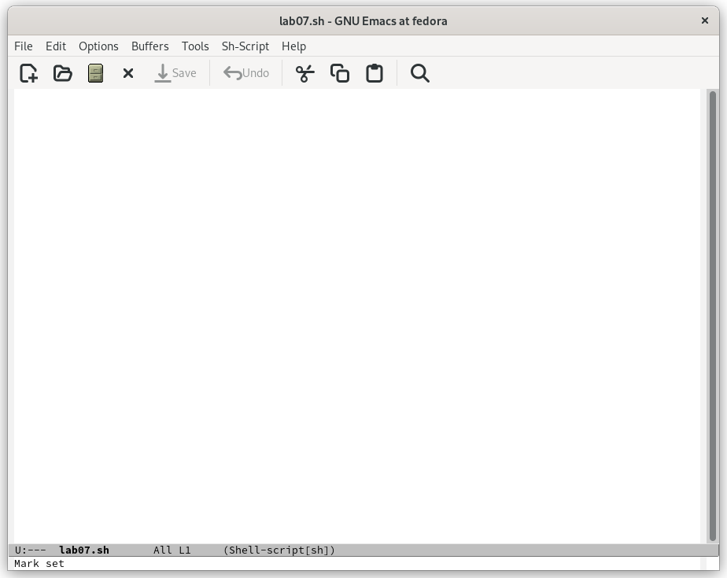

Редактор Emacs

## Выполнение лабораторной работы

3. Наберите текст, который дан.
4. Сохранить файл с помощью комбинации Ctrl-x Ctrl-s (C-x C-s). (рис. [-@fig:003])

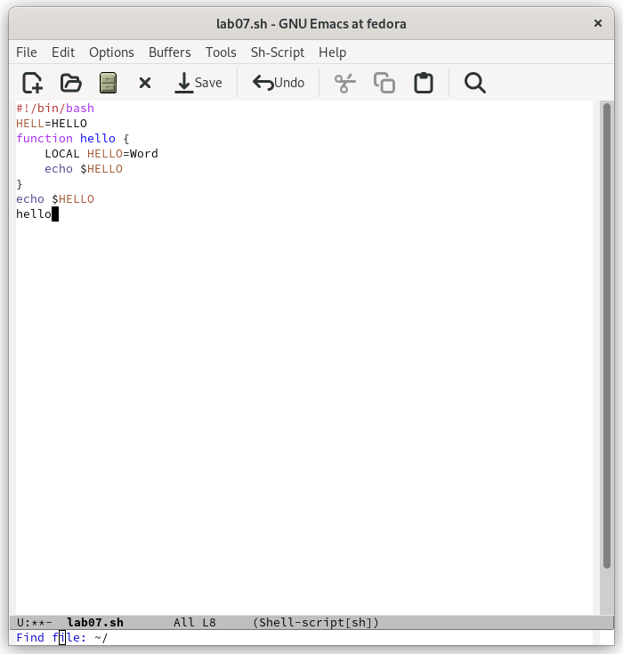

Текст в редакторе

## Выполнение лабораторной работы

5. Проделать с текстом стандартные процедуры редактирования, каждое действие должно осуществляться комбинацией клавиш. 5.1. Вырезать одной командой целую строку (С-k). (рис. [-@fig:004])

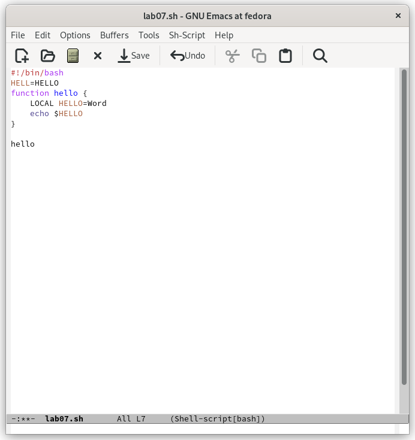

Вырезание строчку

## Выполнение лабораторной работы

5.2. Вставить эту строку в конец файла (C-y). (рис. [-@fig:005])

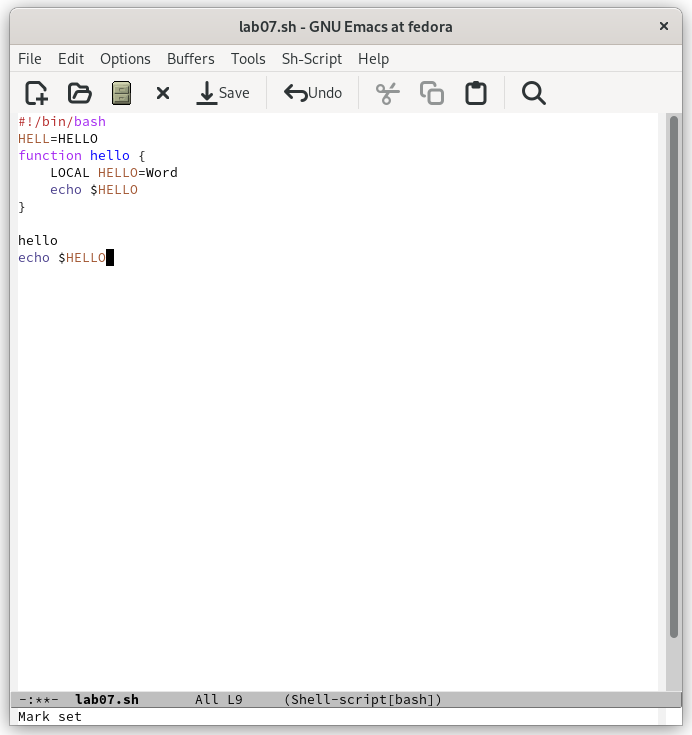

Вставка строчки в конец файла

## Выполнение лабораторной работы

5.3. Выделить область текста (C-space). 5.4. Скопировать область в буфер обмена (M-w). 5.5. Вставить область в конец файла. (рис. [-@fig:006])

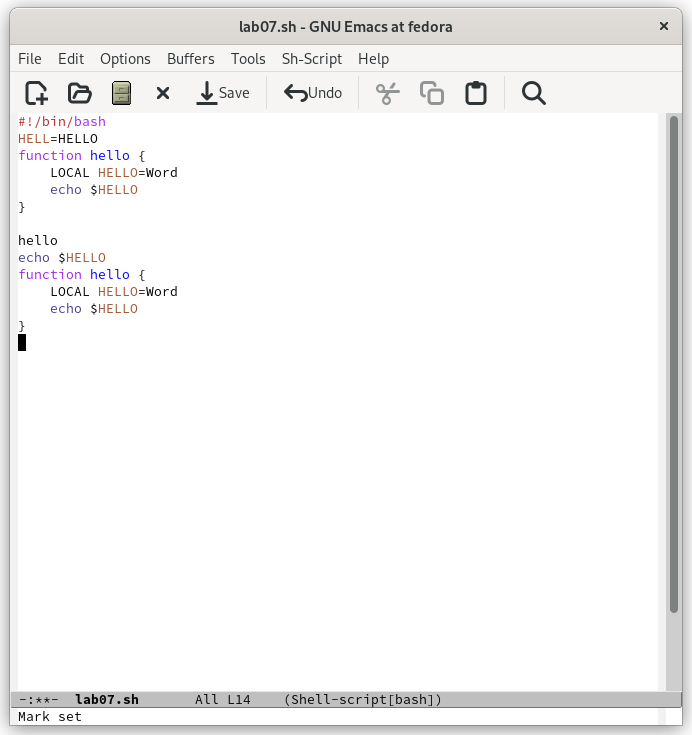

Вставка скопированной области в конец файла

## Выполнение лабораторной работы

5.6. Вновь выделить эту область и на этот раз вырезать её (C-w). (рис. [-@fig:007])

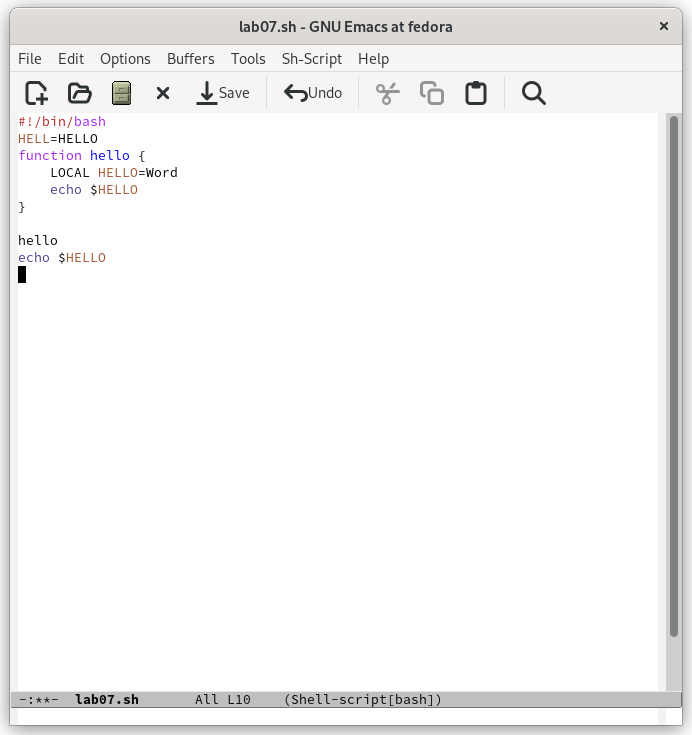

Вырезание области текста

## Выполнение лабораторной работы

5.7. Отмените последнее действие (C-/). (рис. [-@fig:008])

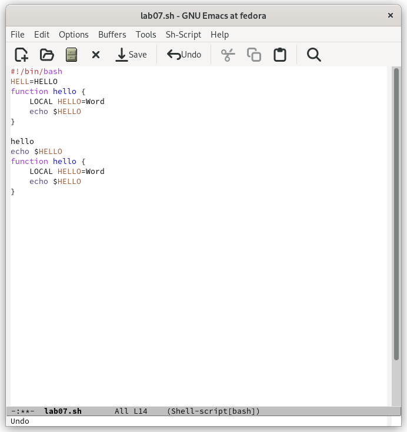

Отмена последнего действия

## Выполнение лабораторной работы

6. Научитесь использовать команды по перемещению курсора. 6.1. Переместите курсор в начало строки (C-a). (рис. [-@fig:009])

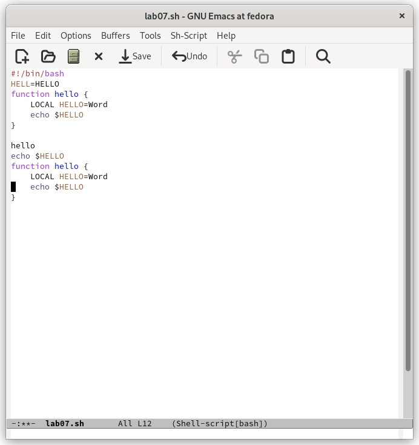

Курсор в начале строки

## Выполнение лабораторной работы

6.2. Переместите курсор в конец строки (C-e). (рис. [-@fig:010])

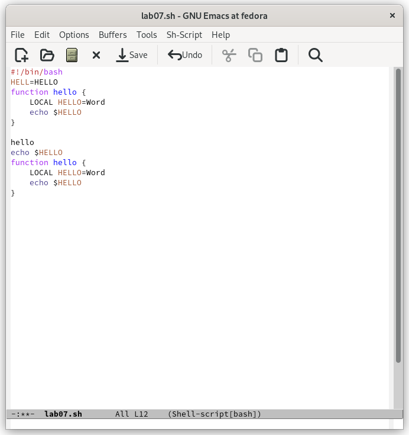

Курсор в конце строки

## Выполнение лабораторной работы

6.3. Переместите курсор в начало буфера (M-<). 6.4. Переместите курсор в конец буфера (M->).

## Выполнение лабораторной работы

7. Управление буферами. 7.1. Вывести список активных буферов на экран (C-x C-b). (рис. [-@fig:011])

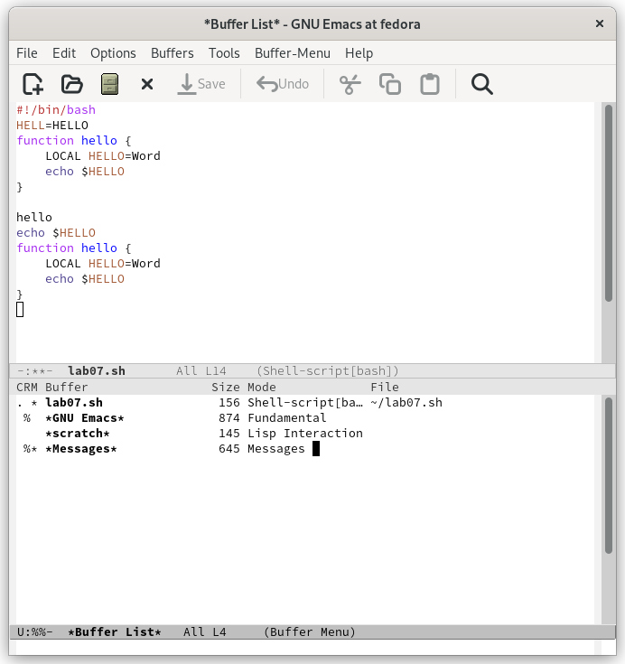

Список активных буферов

## Выполнение лабораторной работы

7.2. Переместитесь во вновь открытое окно (C-x) o со списком открытых буферов и переключитесь на другой буфер. (рис. [-@fig:012])

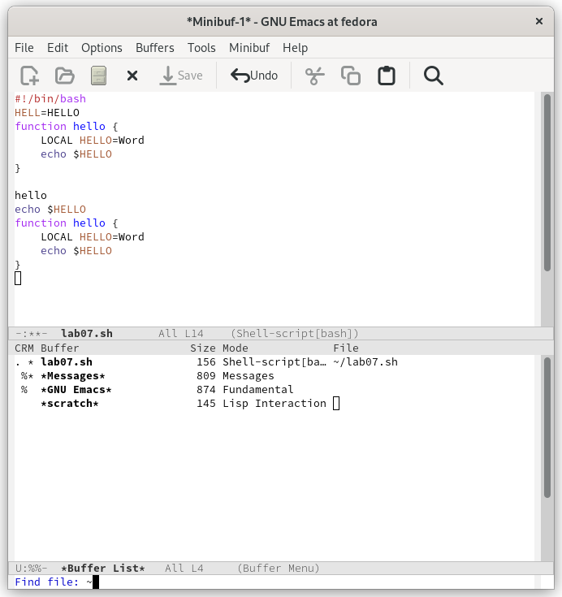

## Выполнение лабораторной работы

7.3. Закройте это окно (C-x 0). 7.4. Теперь вновь переключайтесь между буферами, но уже без вывода их списка на экран (C-x b).

## Выполнение лабораторной работы

8. Управление окнами. 8.1. Поделите фрейм на 4 части: разделите фрейм на два окна по вертикали (C-x 3), а затем каждое из этих окон на две части по горизонтали (C-x 2). (рис. [-@fig:013])

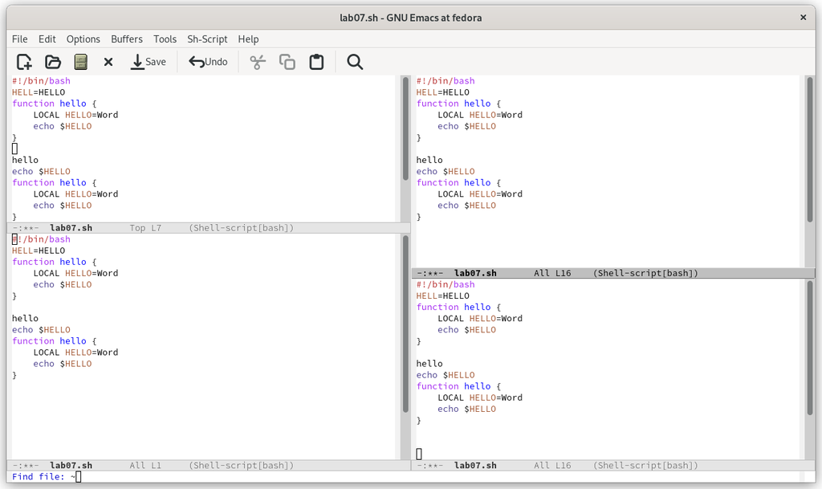

4 окна

## Выполнение лабораторной работы

8.2. В каждом из четырёх созданных окон откройте новый буфер (файл) и введите несколько строк текста. (рис. [-@fig:014])

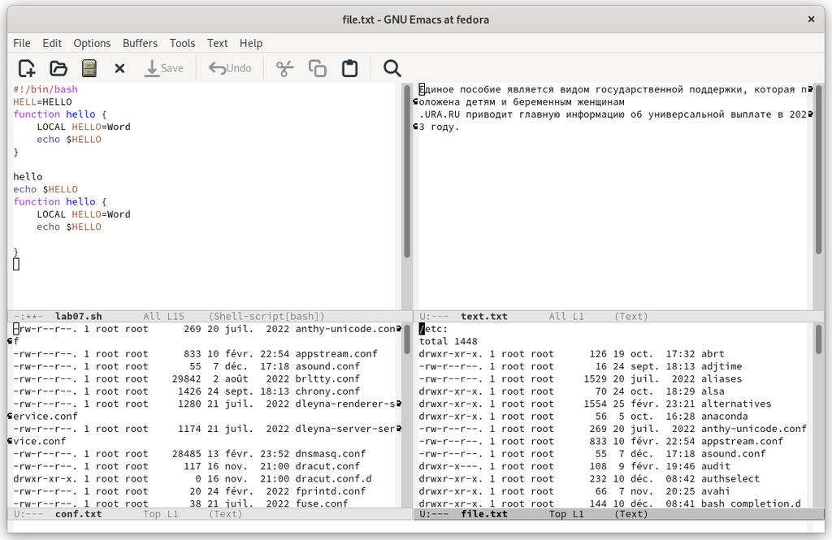

## Выполнение лабораторной работы

9. Режим поиска 9.1. Переключитесь в режим поиска (C-s) и найдите несколько слов, присутствующих в тексте. (рис. [-@fig:015])

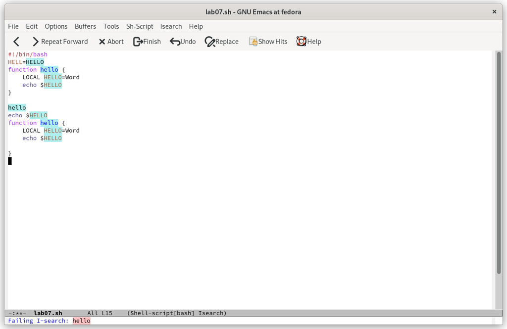

Режим поиска

## Выполнение лабораторной работы

9.2. Переключайтесь между результатами поиска, нажимая C-s. (рис. [-@fig:016])

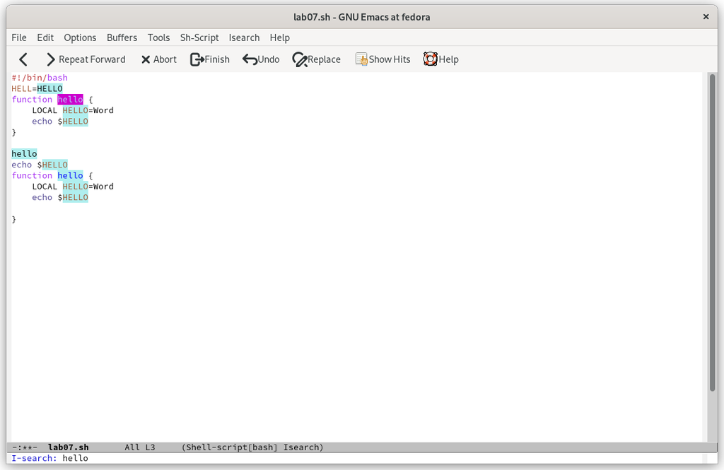

Режим поиска

## Выполнение лабораторной работы

9.3. Выйдите из режима поиска, нажав C-g. 9.4. Перейдите в режим поиска и замены (M-%), введите текст, который следует найти и заменить, нажмите Enter , затем введите текст для замены. После того как будут подсвечены результаты поиска, нажмите ! для подтверждения замены. (рис. [-@fig:017])

## Выполнение лабораторной работы

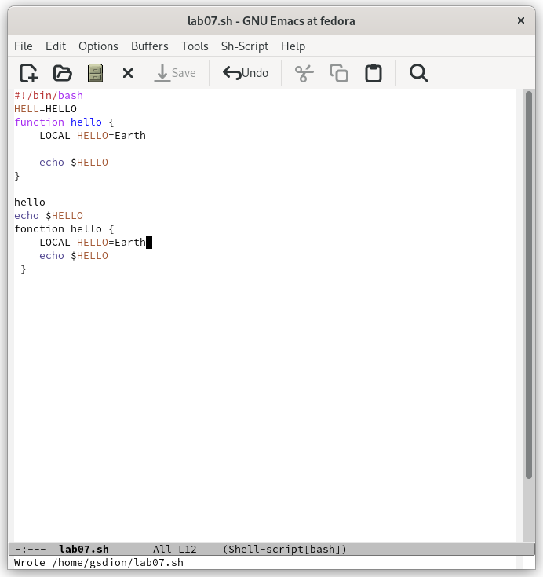

Режим поиска и замены

## Выполнение лабораторной работы

9.5. Испробуйте другой режим поиска, нажав M-s o. Объясните, чем он отличается от обычного режима? (рис. [-@fig:018])

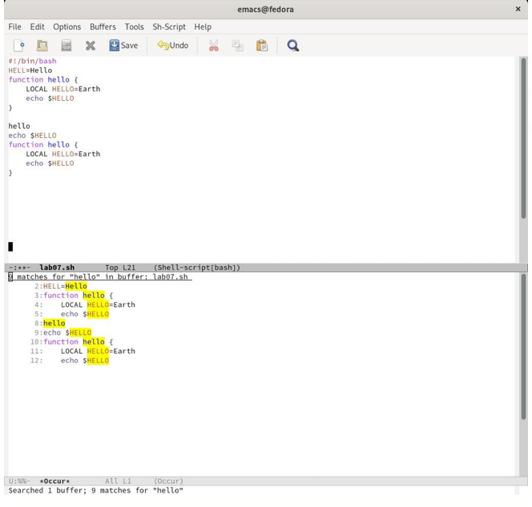

Другой режим поиска

## Выводы

В процессе выполнения лабораторной работы я получил практические навыки работы в редакторе Emacs.

## Список литературы

1. Emacs для начинающих [Электронный ресурс]. URL: https://www.opennet.ru/docs/RUS/emacs_begin/.

Спасибо за внимание!